Saltar al contenido principal

# ¿Qué es una API y cómo se usa en R?

Un ejemplo sencillo con datos macroeconómicos del Banco Mundial

Autor/a

Programación 1 — Introducción a R

Fecha de publicación

1 de enero de 2026

# 1. ¿Qué es una API?

Una **API** (*Application Programming Interface*) es una dirección web (URL) pensada para que la lea un **programa** y no una persona. Si escribes `www.upna.es` en el navegador recibes una página para leer; si escribes la URL de una API recibes **datos**, normalmente en formato **JSON**.

```
Tu script en R ──(1) petición: una URL──▶ Servidor de la API
               ◀─(2) respuesta: JSON────
```

# 2. ¿Para qué sirve?

- Obtener datos **directamente desde el código**, sin entrar en una web, buscar el fichero y descargarlo a mano.
- Acceder a datos de **organismos oficiales** (Banco Mundial, Eurostat, BCE, FMI, INE…) y de otros servicios (buscadores científicos, meteorología, redes sociales).
- Pedir solo **lo que necesitas**: un país, un indicador, un rango de años.

# 3. Ventajas (y un inconveniente)

| Ventajas | Explicación |
| --- | --- |
| **Datos actualizados** | Ejecutas el script otra vez y tienes la última versión. |
| **Reproducible** | El código dice de dónde salen los datos y qué se pidió exactamente. |
| **A medida** | Pides solo el país, el indicador y los años que necesitas. |
| **Automatizable** | Cambiar de país o de indicador es cambiar una palabra de la URL. |

**Inconveniente:** necesitas conexión a internet y los datos pueden cambiar con el tiempo. Por eso conviene **guardar una copia con fecha** de lo que descargas.

# 4. Cómo se usa: los tres pasos

1. **Construir la URL.** Tiene una base, una ruta y unos parámetros:

   ```
   https://api.worldbank.org/v2/country/ESP/indicator/NY.GDP.MKTP.KD.ZG?format=json&date=2010:2023
   \_____________________/\_____/\_____/\_/\_________/\_____________________/\____________________/
   base                  versión país   código  indicador   parámetros: formato y años
   ```

2. **Pedirla desde R** con `fromJSON()` (paquete `jsonlite`), que descarga el JSON y lo convierte en objetos de R.
3. **Quedarte con la parte útil** y convertirla en una tabla.

**TipAntes de programar**

Pega siempre la URL en el navegador: verás el JSON tal como lo recibirá R.

# 5. Ejemplo: crecimiento del PIB de España

Usamos la **API del Banco Mundial**, gratuita y sin registro. El indicador `NY.GDP.MKTP.KD.ZG` es el **crecimiento anual del PIB (%)**.

```r
library(tidyverse)
library(jsonlite)
```

**Paso 1: construir la URL**

```r
pais      <- "ESP"
indicador <- "NY.GDP.MKTP.KD.ZG"

url <- paste0("https://api.worldbank.org/v2/country/", pais,
              "/indicator/", indicador,
              "?format=json&date=2010:2023&per_page=100")
url
```

```
[1] "https://api.worldbank.org/v2/country/ESP/indicator/NY.GDP.MKTP.KD.ZG?format=json&date=2010:2023&per_page=100"
```

**Paso 2: descargar**

```r
respuesta <- fromJSON(url)

length(respuesta)     # 2 elementos: [[1]] metadatos, [[2]] los datos
```

```
[1] 2
```

La respuesta del Banco Mundial tiene **dos partes**: el primer elemento son metadatos (páginas, total de registros) y el segundo contiene los datos.

**Paso 3: quedarnos con los datos y ordenarlos**

```r
pib <- respuesta[[2]] %>%
  as_tibble() %>%
  transmute(anio = as.integer(date),
            crecimiento_pib = value) %>%
  arrange(anio)

pib
```

```
# A tibble: 14 × 2
    anio crecimiento_pib
   <int>           <dbl>
 1  2010          0.0941
 2  2011         -0.640
 3  2012         -2.87
 4  2013         -1.43
 5  2014          1.52
 6  2015          4.06
 7  2016          2.92
 8  2017          2.90
 9  2018          2.40
10  2019          1.96
11  2020        -10.9
12  2021          6.68
13  2022          6.37
14  2023          2.46
```

**Paso 4: un gráfico**

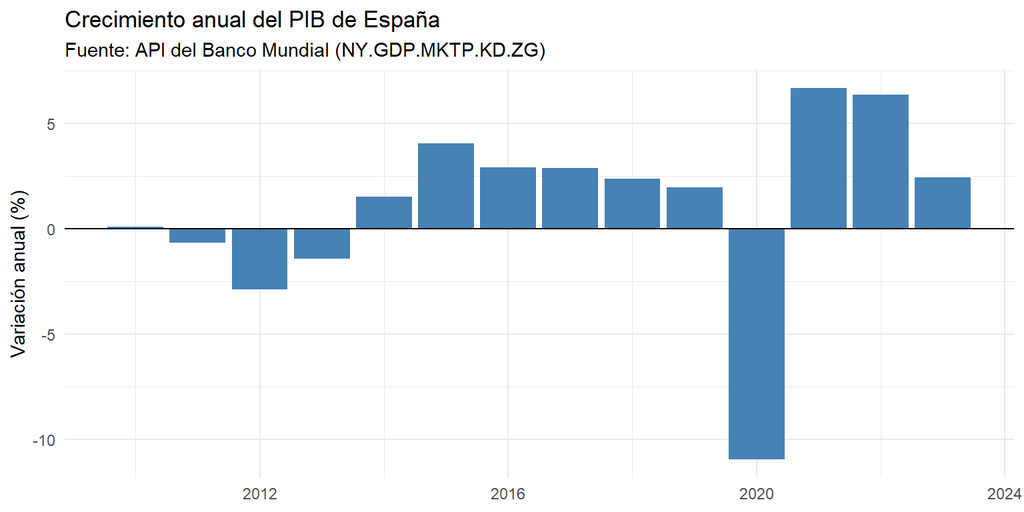

```r
ggplot(pib, aes(x = anio, y = crecimiento_pib)) +
  geom_col(fill = "steelblue") +
  geom_hline(yintercept = 0) +
  labs(title = "Crecimiento anual del PIB de España",
       subtitle = "Fuente: API del Banco Mundial (NY.GDP.MKTP.KD.ZG)",
       x = NULL, y = "Variación anual (%)") +
  theme_minimal()
```

**Guardar una copia con fecha** (buena práctica, para poder reproducir el análisis más adelante):

```r
write_csv(pib, paste0("pib_espana_", Sys.Date(), ".csv"))
```

# 6. Pruébalo tú

Cambia **solo dos valores** en el paso 1 y vuelve a ejecutar todo:

- `pais`: `"FRA"`, `"DEU"`, `"ITA"`, `"USA"`…
- `indicador`: `"FP.CPI.TOTL.ZG"` (inflación anual, %) o `"SL.UEM.TOTL.ZS"` (desempleo, % de la población activa).

Recuerda cambiar también el título del gráfico.

**NotaSi algo falla**

Un error `HTTP error 404` o `400` significa que la URL está mal escrita (código de país o indicador incorrectos). Pégala en el navegador y compárala con la documentación: https://datahelpdesk.worldbank.org/knowledgebase/topics/125589. Si el error es de conexión, revisa tu internet y vuelve a intentarlo.